# Analysis of Alternative Forced Choice (AFC) and Likert Scale Response (LSR) as alternative response modes for the fMRI version of the Humour task

## Rationale

As part of the review process of the Bangor Imaging Unit resource request, we were asked to perform a pilot of the Humour Task. The aim was to clarify whether an implicit processing measure (like the reaction time to an alternative forced choice task) or an explicit Likert scale rating were better as an index of irresolvable ambiguity, to collect data during the fMRI version of the task. For this pilot, we focussed on item-level analyses, as both effects of interest are item-centered (more on this below) and we have more items (40 per condition, total 120) than we do participants (10 for each task, total 20), allowing us to maximise statistical power.

The original task consisted of a series of jokes anchored around a double-meaning word (e.g., *"Two cellphones got married, the* *reception** was fantastic"*), and non-joke sentences where the context was manipulated to remove the ambiguity biasing the interpretation to each of the ambiguous' word senses (e.g.,* Sense1: "Two friends got married, the **reception** was fantastic"*; Sense2:* "Two cellphones were tested, the **reception** was fantastic"*). After reading the sentence, the participants had to rate how related the ambiguous word was to its two possible senses (e.g. how related is "reception" to "party" and to "signal") in two separate 7-point Likert scale ratings. After this, they had to indicate whether the sentence was a joke or not, and how funny they found it on another 7-point Likert scale judgement.

The main effect observed in the behavioural task described above consisted of greater irresolvable ambiguity for jokes relative to non-jokes. In this version of the task, irresolvable ambiguity was indexed by a smaller difference (delta) between the Likert scale ratings to both possible senses of an ambiguous word. This difference was smaller when the sentence was a joke than when it was a non-joke, suggesting that participants activated both meanings to a similar extent. An analysis of this ambiguity effect across items found that jokes exhibited it at a greater degree than non-jokes; within the joke category, those jokes containing irresolvable ambiguity exhibited it to a greater degree than those that did not. Another important effect was an association between the delta (difference between ratings) and the funniness of the material read. The proposed adaptation, to optimise the trial duration for multivariate analysis, was to collapse the two separate Likert scale relatedness ratings for both senses into one, where participants had to place the word along a 7-point Likert scale where each extreme of the scale represented one of both possible senses (see Figure below).

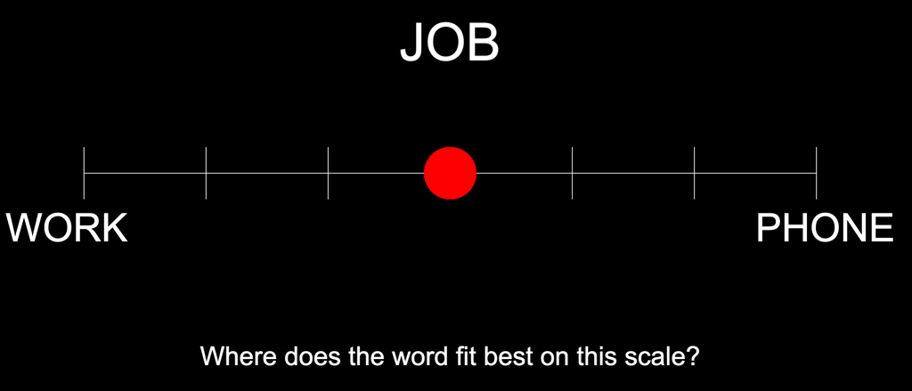

During the review, the question was raised whether an implicit measure, like the time it takes to make a decision between both senses, could be a stronger indicator of the degree to which both senses were activated (if participants activate both senses of the word "reception", as "signal" and "party", they would vacillate and hence take longer to make the decision), as Likert scales are not always reliable. However, since the behavioural task showed a counterintuitive priming effect for high-ambiguity items (they were read and decided faster, opposite to conventional ambiguity effects in priming), a pilot study was considered necessary. We designed an alternative response mode for this task consisting of a 2-Alternative Forced Choice response between the two possible senses of the word, in order to test whether it worked better than the Likert scale response (see Figure below)

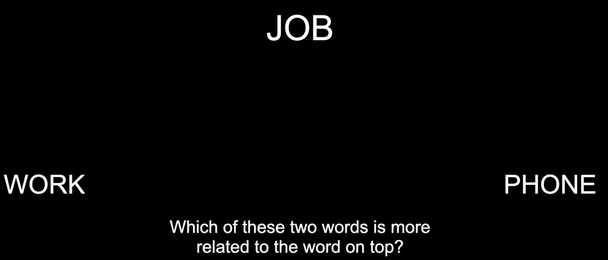

Therefore, a pilot study was performed using Pavlovia/Prolific. We collected 10 participants' performance in each version of the task (AFC = Alternative Forced Choice; LSR = Likert Scale Response). After inspecting the data quality, we carried out all participants to the analysis phase. The analyses reported in this notebook aim to answer the question: which response method yields the strongest effects analogous to that observed in the non-fMRI (i.e., behavioural) version of the task? We evaluated the following questions for each method:

1. Are jokes rated as funnier than non-jokes (a sanity check for data quality and participant attention)?
2. Do jokes display an ambiguity effect to a greater extent than non-jokes (AFC = slower reaction times; LSR = the word is placed closer to the center of the scale)
3. Does this ambiguity effect correlate with funniness, as observed in the behavioural task?

In the rest of the notebook, we will answer these three questions for each method in turn. After we have done this, we will compare the size of the effects observed, and compare both methods on their ability produce a ranking of items in line with this ambiguity effect (i.e., with jokes displaying it to a greater extent than non-jokes). Let us begin with the Alternative Forced Choice.

As a first step, we aggregated the data at the item-level, averaging the responses of all 10 participants for each item. We included in the analysis only those responses where where the participant correctly identified whether the sentence was a joke or not (see aggregation script in OSF storage folder 'scripts': https://osf.io/phnjz/files/osfstorage).

#### Import things we need and configure plotting:

```python
import pandas as pd
import numpy as np
import pingouin as pg
import seaborn as sns; sns.set_style('white')
import matplotlib.pyplot as plt
from scipy import stats

# make plots appear directly in the notebook
%matplotlib inline
```

___

## 1. Alternative Forced Choice (AFC) Analysis

### Load AFC data

```python
afc = pd.read_csv('data/Master_AFC_correct_full.csv')
```

### 1.1 Are jokes rated as funnier?

This is a sanity check. If participants were paying attention and the stimulus set worked, then jokes should be rated as funnier than non-jokes. We test this through a t-test across condition (collapsing Sense1 and Sense2, since we do not expect differences across the two non-joke senses of the sentences)

Null: mean funniness of jokes = non-jokes.

```
t = 26.94, p = 0.000
```

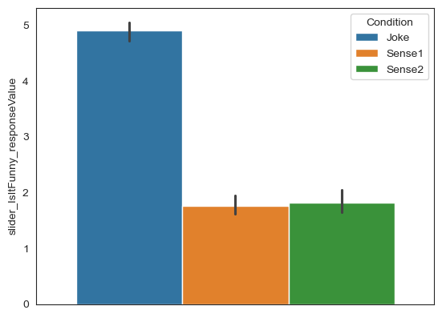

```python
# compute t-test
t, p = stats.ttest_ind(
    afc[afc.Condition == 'Joke'].slider_IsItFunny_responseValue,
    afc[afc.Condition != 'Joke'].slider_IsItFunny_responseValue
)
print(f"t = {t:.2f}, p = {p:.3f}")

# plot
sns.barplot(data=afc, y='slider_IsItFunny_responseValue', hue='Condition')
plt.show()
```

#### *Figure 1. Jokes are funnier than non-jokes in the AFC sample.*

*Note: Sense1 and Sense2 are the sentences where we manipulated the context of the joke to remove the ambiguity. Together, we refer to them as 'non-jokes'.*

This sanity check shows that indeed, jokes were significantly funnier than non-jokes in this sample

### 1.2. Does it take longer to choose which word is more related to the ambiguous word for jokes vs non-jokes?

This is the effect of interest. The logic is: if people are accessing both meanings in ambiguous items (jokes), they would vacilate when making the decision and this would be reflected in longer Reaction Times (RT). Therefore, the question this analysis asks is: Do jokes have longer reaction times?

NOTE: Prolific yielded some RTs over 30/40 seconds. We winsorised the 5% extreme RTs before item-level aggregation.

Run two-sided paired t-tests to check whether participants were slower to respond to jokes or non-jokes (both, collapsing across Sense1 and Sense2, and separately for each of the senses). Save the results for displaying in the plot below and later comparison with the other method.

*Null: Joke RT = Non-joke (or sense1/2) RT.*

```python
# t-test and effect size calculation for joke vs non-joke
ttest_results = pg.ttest(afc[afc.Condition=='Joke']['key_resp_relatedness.rt_winsor'],
                    afc[afc.Condition!='Joke']['key_resp_relatedness.rt_winsor'],
                         paired=False)

t = ttest_results.T.values[0]
p = ttest_results['p-val'].values[0]
bf = ttest_results.BF10.values[0]
coh = ttest_results['cohen-d'].values[0]
hed = pg.compute_effsize(afc[afc.Condition=='Joke']['key_resp_relatedness.rt_winsor'],
                    afc[afc.Condition!='Joke']['key_resp_relatedness.rt_winsor'],
                             paired=False, eftype='hedges')

# t-test and effect size calculation for joke vs sense1
ttest_results1 = pg.ttest(afc[afc.Condition=='Joke']['key_resp_relatedness.rt_winsor'],
                    afc[afc.Condition=='Sense1']['key_resp_relatedness.rt_winsor'],
                         paired=True)

t1 = ttest_results1.T.values[0]
p1 = ttest_results1['p-val'].values[0]
bf1 = ttest_results1.BF10.values[0]
coh1 = ttest_results1['cohen-d'].values[0]
hed1 = pg.compute_effsize(afc[afc.Condition=='Joke']['key_resp_relatedness.rt_winsor'],
                    afc[afc.Condition=='Sense1']['key_resp_relatedness.rt_winsor'],
                             paired=True, eftype='hedges')

# t-test and effect size calculation for joke vs sense2
ttest_results2 = pg.ttest(afc[afc.Condition=='Joke']['key_resp_relatedness.rt_winsor'],
                    afc[afc.Condition=='Sense2']['key_resp_relatedness.rt_winsor'],
                         paired=True)

t2 = ttest_results2.T.values[0]
p2 = ttest_results2['p-val'].values[0]
bf2 = ttest_results2.BF10.values[0]
coh2 = ttest_results2['cohen-d'].values[0]
hed2 = pg.compute_effsize(afc[afc.Condition=='Joke']['key_resp_relatedness.rt_winsor'],
                    afc[afc.Condition=='Sense2']['key_resp_relatedness.rt_winsor'],
                             paired=True, eftype='hedges')
```

Plot the results, displaying Cohen d, Hedges g (more appropriate effect size measure for sample size) and Bayes Factor (BF). This will give us useful metrics to compare with the Likert Scale Response method

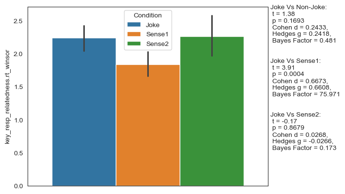

```python
sns.barplot(data=afc,y='key_resp_relatedness.rt_winsor',hue='Condition')
plt.annotate('Joke Vs Non-Joke: \n t = {:.2f} \n p = {:.4f} \n Cohen d = {:.4f}, \n Hedges g = {:.4f}, \n Bayes Factor = {}'.format(t[0],p,coh,hed,bf), xy=(1.01, 0.8), xycoords='axes fraction')
plt.annotate('Joke Vs Sense1: \n t = {:.2f} \n p = {:.4f} \n Cohen d = {:.4f}, \n Hedges g = {:.4f}, \n Bayes Factor = {}'.format(t1[0],p1,coh1,hed1,bf1), xy=(1.01, 0.5), xycoords='axes fraction')
plt.annotate('Joke Vs Sense2: \n t = {:.2f} \n p = {:.4f} \n Cohen d = {:.4f}, \n Hedges g = {:.4f}, \n Bayes Factor = {}'.format(t2[0],p2,coh2,hed2,bf2), xy=(1.01, 0.2), xycoords='axes fraction')
plt.show()
```

#### *Figure 2. Jokes have longer RTs than Sense1, but not Sense2.*

The results show no effect for Joke > Non-Joke (collapsing Sense1 and Sense2). When we break it down, we observe a significant effect of moderate size with strong Bayes Factor evidence for Joke > Sense1, but this effect is absent for Joke > Sense2. In conclusion, the effect observed in the original task does not fully and consistently replicate using the AFC method of response.

Let us turn our attention to the next question:

### 1.3. Does the ambiguity index (reaction time) correlate with funniness?

This is another effect we observed in the behavioural paradigm. The effect consisted on a correlation between the degree to which participants activated both senses of the ambiguous word (indexed by a smaller difference between relatedness ratings of the ambiguous word to both of its senses) and how funny they found the joke.

We will now check if the AFC mode of response shows this property. We will do this by correlating the time participants took to select which word is more related to the ambiguous word (indexed by RT) and how funny they found the sentence read.

Perform a Pearson correlation separately for joke and non-joke, given that we would not necessarily predict the effect for non-jokes. We store the results (r, p) and display them in a scatterplot to show the effect.

*Null: RT and funniness are uncorrelated*

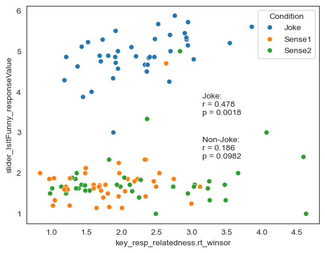

```python
# perform correlations and save the results for plotting
r_afc_j,p_afc_j = stats.pearsonr(afc[afc.Condition=='Joke']['slider_IsItFunny_responseValue'], afc[afc.Condition=='Joke']['key_resp_relatedness.rt_winsor'])
n_afc_j = afc.shape[0]

r_afc_nj,p_afc_nj = stats.pearsonr(afc[afc.Condition!='Joke']['slider_IsItFunny_responseValue'], afc[afc.Condition!='Joke']['key_resp_relatedness.rt_winsor'])
n_afc_nj = afc.shape[0]

# do and annotate the scatterplot
sns.scatterplot(data=afc, x = 'key_resp_relatedness.rt_winsor', y = 'slider_IsItFunny_responseValue', hue='Condition')

plt.annotate('Joke: \nr = {:.3f} \np = {:.4f}'.format(r_afc_j,p_afc_j), xy=(0.6, 0.5), xycoords='axes fraction')
plt.annotate('Non-Joke: \nr = {:.3f} \np = {:.4f}'.format(r_afc_nj,p_afc_nj), xy=(0.6, 0.3), xycoords='axes fraction')
plt.show()
```

#### *Figure 3. Joke funniness shows a correlation with reaction time in the AFC response method, but non-joke funniness does not.*

This analysis reveals an effect in line with the original version of the task. As expected, the funniness of the jokes correlated with reaction time using the AFC response method, in line with the idea that perceiving both meanings is associated with how funny we find the jokes. Non-joke stimuli did not show this effect, in line with expectations.

Having tested both effects, we now move to the analysis of the Likert Scale Response Method  
___

## 2. Likert Scale Response (LSR) Analysis

### Load LSR data

```python
lsr = pd.read_csv('data/Master_LSR_correct_full.csv')
```

### 2.1 Are jokes rated as funnier?

We first repeat the sanity check we performed for AFC, to confirm whether participants were paying attention by checking if jokes were rated to be funnier than non-jokes. Again, we test this through a t-test across condition (collapsing Sense1 and Sense2, since we do not expect differences across the two non-joke senses of the sentences).

*Null: mean funniness of jokes = non-jokes.*

```
t = 23.45, p = 0.000
```

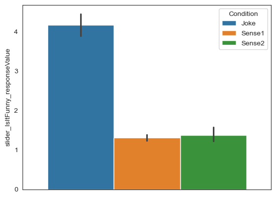

```python
# compute t-test
t, p = stats.ttest_ind(
    lsr[lsr.Condition == 'Joke'].slider_IsItFunny_responseValue,
    lsr[lsr.Condition != 'Joke'].slider_IsItFunny_responseValue
)
print(f"t = {t:.2f}, p = {p:.3f}")

# plot
sns.barplot(data=lsr, y='slider_IsItFunny_responseValue', hue='Condition')
plt.show()
```

#### *Figure 4. Jokes are funnier than non-jokes in the LSR sample.*

The sanity check shows that jokes were significantly funnier than non-jokes in this sample as well.

### 2.2. Are the ambiguous words placed closer to the center of the Likert scale for jokes vs non-jokes?

This is the effect of interest for the LSR version. The logic is: if people are accessing both meanings in ambiguous items (jokes), they would struggle placing the word closer to either end of the Likert scale (where each end represents one of the two meanings), and would place it instead closer to the center.

Since this was a 7-point Likert scale, the middle point is 4. To compute *DistanceFromCenter *we need to take the absolute value resulting from subtracting four minus the data point:**

$$ D = abs(4 - x) $$

Since 4 was the middle point of the 7-point Likert scale, with each sense of the ambiguous word at the extremes, the smaller the distance, the harder it was for the participant to decide to associate the ambiguous word with either of its senses, denoting ambiguity that is harder to resolve. Conversely, the greater the distance from the center, the stronger the association with one of the two senses of the word.

Therefore, we operationalised the question for this analysis is as follows: do jokes show a smaller distance from center relative to non-jokes? Similar to the AFC version, we first perform two-sided t-tests comparing jokes and non-jokes (both, collapsing across Sense1 and Sense2, and separately for each of the senses) to check whether jokes or non-jokes showed greater ambiguity indexed by smaller distances from the center. We save the results for displaying in the plot below and compare effect sizes with the AFC method.

*Null: Joke Distance = Non-joke (or sense1/2) Distance.*

```python
# t-test and effect size calculation for joke vs non-joke
ttest_results = pg.ttest(lsr[lsr.Condition=='Joke']['DistanceFromCenter'],
                    lsr[lsr.Condition!='Joke']['DistanceFromCenter'],
                         paired=False)

t = ttest_results.T.values[0]
p = ttest_results['p-val'].values[0]
bf = ttest_results.BF10.values[0]
coh = ttest_results['cohen-d'].values[0]
hed = pg.compute_effsize(lsr[lsr.Condition=='Joke']['DistanceFromCenter'],
                    lsr[lsr.Condition!='Joke']['DistanceFromCenter'],
                             paired=False, eftype='hedges')

# t-test and effect size calculation for joke vs sense1
ttest_results1 = pg.ttest(lsr[lsr.Condition=='Joke']['DistanceFromCenter'],
                    lsr[lsr.Condition=='Sense1']['DistanceFromCenter'],
                         paired=True)

t1 = ttest_results1.T.values[0]
p1 = ttest_results1['p-val'].values[0]
bf1 = ttest_results1.BF10.values[0]
coh1 = ttest_results1['cohen-d'].values[0]
hed1 = pg.compute_effsize(lsr[lsr.Condition=='Joke']['DistanceFromCenter'],
                    lsr[lsr.Condition=='Sense1']['DistanceFromCenter'],
                             paired=True, eftype='hedges')

# t-test and effect size calculation for joke vs sense2
ttest_results2 = pg.ttest(lsr[lsr.Condition=='Joke']['DistanceFromCenter'],
                    lsr[lsr.Condition=='Sense2']['DistanceFromCenter'],
                         paired=True)

t2 = ttest_results2.T.values[0]
p2 = ttest_results2['p-val'].values[0]
bf2 = ttest_results2.BF10.values[0]
coh2 = ttest_results2['cohen-d'].values[0]
hed2 = pg.compute_effsize(lsr[lsr.Condition=='Joke']['DistanceFromCenter'],
                    lsr[lsr.Condition=='Sense2']['DistanceFromCenter'],
                             paired=True, eftype='hedges')
```

Plot the results, displaying Cohen d, Hedges g (more appropriate effect size measure for sample size) and Bayes Factor (BF). This will give us useful metrics to compare with the AFC method

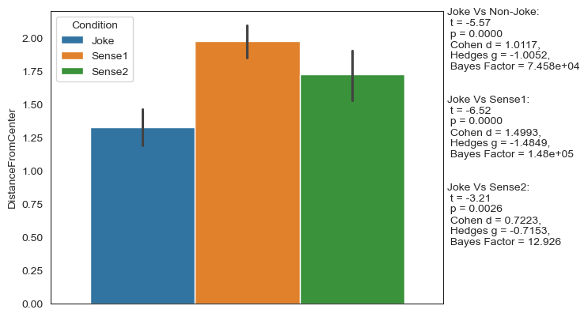

```python
sns.barplot(data=lsr,y='DistanceFromCenter',hue='Condition')
plt.annotate('Joke Vs Non-Joke: \n t = {:.2f} \n p = {:.4f} \n Cohen d = {:.4f}, \n Hedges g = {:.4f}, \n Bayes Factor = {}'.format(t[0],p,coh,hed,bf), xy=(1.01, 0.8), xycoords='axes fraction')
plt.annotate('Joke Vs Sense1: \n t = {:.2f} \n p = {:.4f} \n Cohen d = {:.4f}, \n Hedges g = {:.4f}, \n Bayes Factor = {}'.format(t1[0],p1,coh1,hed1,bf1), xy=(1.01, 0.5), xycoords='axes fraction')
plt.annotate('Joke Vs Sense2: \n t = {:.2f} \n p = {:.4f} \n Cohen d = {:.4f}, \n Hedges g = {:.4f}, \n Bayes Factor = {}'.format(t2[0],p2,coh2,hed2,bf2), xy=(1.01, 0.2), xycoords='axes fraction')
plt.show()
```

#### *Figure 5. Jokes have shorter distances from the center of the Likert Scale Response than Non-jokes.*

Let us turn our attention to the next question:

### 2.3. Does the Distance from Center correlate with funniness?

As a reminder, in the original paradigm we observed a correlation between the degree to which participants activated both senses of the ambiguous word (indexed by a smaller difference between relatedness ratings of the ambiguous word to both of its senses) and how funny they found the joke.

Like for the AFC response method, we tested whether this effect was present for the LSR method by correlating to what degree participants perceived both meanings (indexed by the distance from the center of a scale where each extreme is one of the senses of the ambiguous word) and how funny they found the sentence read.

Perform a Pearson correlation separately for joke and non-joke, given that we would not necessarily predict the effect for non-jokes. We store the results (r, p) and display them in a scatterplot to show the effect.

*Null: RT and funniness are uncorrelated*

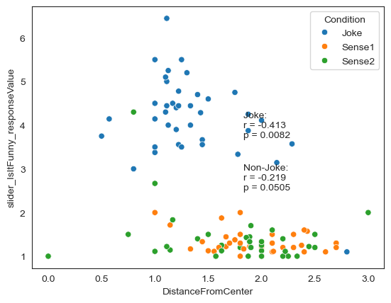

```python
# perform correlations and save the results for plotting
r_lsr_j,p_lsr_j = stats.pearsonr(lsr[lsr.Condition=='Joke']['slider_IsItFunny_responseValue'], lsr[lsr.Condition=='Joke']['DistanceFromCenter'])
n_lsr_j = lsr.shape[0]

r_lsr_nj,p_lsr_nj = stats.pearsonr(lsr[lsr.Condition!='Joke']['slider_IsItFunny_responseValue'], lsr[lsr.Condition!='Joke']['DistanceFromCenter'])
n_lsr_nj = lsr.shape[0]

sns.scatterplot(data=lsr, x = 'DistanceFromCenter', y = 'slider_IsItFunny_responseValue', hue='Condition')

# do and annotate the scatterplot
plt.annotate('Joke: \nr = {:.3f} \np = {:.4f}'.format(r_lsr_j,p_lsr_j), xy=(0.6, 0.5), xycoords='axes fraction')
plt.annotate('Non-Joke: \nr = {:.3f} \np = {:.4f}'.format(r_lsr_nj,p_lsr_nj), xy=(0.6, 0.3), xycoords='axes fraction')
plt.show()
```

#### *Figure 6. Joke funniness shows a correlation with distance from center in the LSR response method, but non-joke funniness does not.*

Similar to the AFC method, this analysis reveals an effect in line with the original version of the task. As expected, the funniness of the jokes exhibited a negative correlation with distance from center using the LSR response method, in line with the idea that perceiving both meanings is associated with how funny we find the jokes. Non-joke stimuli did not show this effect (although it approached significance), in line with expectations.

Having answered the questions for both tasks, we now move to comparing them in terms of their ability to differentiate between jokes and non-jokes using their respective ambiguity indexes.  
___

## 3. Comparing effect sizes

In the analysis of the ambiguity index, the AFC method showed an ambiguity effect in the expected direction only for Joke > Sense1 (Joke > Non-joke and Joke > Sense 2 showed no significant effects). The LSR task showed significant ambiguity effects for both, Joke > Non-joke and Joke > Sense1/2). The only effect exhibited by both tasks in common (Joke > Sense1) had an effect size was more than twice as large for LSR than for AFC. We will now test if LSR's Cohen d is significantly greater than that of AFC. We first define a function to compare the sizes:

```python
def compare_cohens_d_independent(d1, n1, d2, n2):
    """
    Compares two independent Cohen's d values (e.g., d_z from paired samples).

    Args:
        d1 (float): Cohen's d for the first group/method.
        n1 (int): Sample size for the first group/method (number of pairs if d_z).
        d2 (float): Cohen's d for the second group/method.
        n2 (int): Sample size for the second group/method (number of pairs if d_z).

    Returns:
        tuple: (z_statistic, p_value_one_tailed, p_value_two_tailed)
               Returns (None, None, None) if sample sizes are too small or d values are extreme.
    """
    if n1 <= 1 or n2 <= 1: # Variance formula requires N in denominator
        print("Error: Sample sizes (n1, n2) must be greater than 1.")
        return None, None, None

    # Approximate variance for Cohen's d_z (from paired samples)
    # Or for Cohen's d from one-sample t-test
    var_d1 = (1/n1) + (d1**2 / (2*n1))
    var_d2 = (1/n2) + (d2**2 / (2*n2))

    # Standard error of the difference between the two d values
    se_diff_d = np.sqrt(var_d1 + var_d2)

    if se_diff_d == 0:
        print("Error: Standard error of the difference is zero. Cannot compute Z-statistic.")
        return None, None, None

    # Z-statistic for the difference
    z_statistic = (d1 - d2) / se_diff_d

    # P-values
    # One-tailed: tests if d1 is significantly greater than d2
    p_value_one_tailed_d1_gt_d2 = stats.norm.sf(z_statistic) # sf is survival function (1 - cdf)

    # Two-tailed: tests if d1 is significantly different from d2
    p_value_two_tailed = 2 * stats.norm.sf(np.abs(z_statistic))

    return z_statistic, p_value_one_tailed_d1_gt_d2, p_value_two_tailed
```

Now we run the comparison using the effect sizes we observed

```python
d_LSR = 1.5  # Cohen's d for LSR (Joke > Sense1)
N_LSR = 40   # Sample size for LSR method

d_AFC = 0.66  # Cohen's d for AFC (Joke > Sense1)
N_AFC = 40   # Sample size (number of pairs) for AFC method

print(f"Comparing d_LSR = {d_LSR} (N={N_LSR}) with d_AFC = {d_AFC} (N={N_AFC}):")

Z, p_one_tailed, p_two_tailed = compare_cohens_d_independent(d_LSR, N_LSR, d_AFC, N_AFC)

if Z is not None:
    print(f"  Z-statistic for the difference between d_LSR and d_AFC (Joke > Sense1): {Z:.4f}")
    print(f"  P-value (one-tailed, H1: d_LSR > d_AFC): {p_one_tailed:.4f}")
    print(f"  P-value (two-tailed, H1: d_LSR != d_AFC): {p_two_tailed:.4f}")

    if p_one_tailed < 0.05: # Setting alpha = 0.05
        print("  Result: The effect size for LSR is significantly larger than for AFC (one-tailed test).")
    else:
        print("  Result: The effect size for LSR is not significantly larger than for AFC (one-tailed test).")
```

```
Comparing d_LSR = 1.5 (N=40) with d_AFC = 0.66 (N=40):
  Z-statistic for the difference between d_LSR and d_AFC (Joke > Sense1): 2.9057
  P-value (one-tailed, H1: d_LSR > d_AFC): 0.0018
  P-value (two-tailed, H1: d_LSR != d_AFC): 0.0037
  Result: The effect size for LSR is significantly larger than for AFC (one-tailed test).
```

The results show that, for the only ambiguity effect captured by the AFC (Joke > Sense1), the LSR showed a significantly larger effect size. The LSR also captured significant effects for Joke > Sense2 and Joke > Non-joke in general, rendering it preferable in this sense.

## 4. Ambiguity Ranking Analysis

In the original task, the difference between the similarity rating for the first and second sense (delta) produced a ranking of items in terms of their degree of ambiguity that nicely separated the jokes from the non-jokes. This ranking, as expected, displayed mostly jokes at the top of the ambiguity scale (indexed by delta), and non-jokes at the bottom. Furthermore, it split the jokes into those with the most irresolvable ambiguity at the top, and those with the least below them (but still above the non-jokes).

One final analysis we can perform to test the adequacy of the LSR vs AFC methods is examining how similar the ranking produced by each method to the sensible ranking produced by the original task is. In other words, we can ask: does either index of ambiguity (smaller distance from center for LSR, slower RT for AFC) do a better job separating the jokes from the non-jokes? To test this, we can rank each item based on their index of ambiguity in their respective methods, and then perform two rank correlations, one for each method, comparing its ranking to that produced by the original task. In the case of the LSR method, the index of ambiguity is the distance of each item from the center of the Likert scale, whilst in the case of the AFC method, the index is the reaction time to the forced choice.

The code below ranks the items' ambiguity for each version of the task using the corresponding index, and then computes the Spearman Rho ranked correlation coefficient comparing how similar each method's ranking is compared to the original task

```python
# load original item set
orig = pd.read_csv('data/Original_NoErrors.csv')

# make sure all datasets are in the same order for condition/item
origs = orig.sort_values(by=['Condition','ID'])
lsrs = lsr.sort_values(by=['Condition','ID'])
afcs = afc.sort_values(by=['Condition','ID'])

# it wouldn't be appropriate to compare both methods using a Pearson r, since
# they use different response metrics. It's better to rank them by ambiguity
# and then perform a rank correlation

# calculate a measure of rank of ambiguity indexed by each dataset relevant
# column (Distance from Center for LSR, winsorised RT for AFC, Delta for original)
lsrs['Rank'] = lsrs['DistanceFromCenter'].rank(method='first').astype(int)
origs['Rank'] = origs['Delta'].rank(method='first').astype(int)
afcs['Rank'] = afcs['key_resp_relatedness.rt_winsor'].rank(method='first').astype(int)

# perform the two comparisons: the original ranking vs lsr ranking and afc ranking
r1,p1 = stats.spearmanr(lsrs.Rank,origs.Rank)
r2,p2 = stats.spearmanr(afcs.Rank,origs.Rank)

# display the results
print("Similarity of ambiguity ranking of items per method (Spearman Rho). 0 = no similarity, 1 = identical:")
print("Similarity between original and LSR: rho = {}, p = {}".format(r1,p1))
print("Similarity between original and AFC: rho = {}, p = {}".format(r2,p2))
```

```
Similarity of ambiguity ranking of items per method (Spearman Rho). 0 = no similarity, 1 = identical:
Similarity between original and LSR: rho = 0.5802277935967775, p = 3.77472682513258e-12
Similarity between original and AFC: rho = -0.06585874019029098, p = 0.4748120858684368
```

The results show that the LSR method produced an ambiguity ranking that is much more similar to that produced by the original task (rho=.58, p<.001). The AFC method produced a very dissimilar ranking (rho=-.06, p=.47).

To visualise the reason behind this difference we can produce swarmplots of the rankings produced by each version, varying the hue of each item according to its kind (Joke vs Non-joke). This way, we can visually inspect if either of the methods produced an ambiguity index where jokes cluster near the high ambiguity end as expected. For the original and LSR method, this would be the bottom of the ranking (more ambiguous items would be expected to have smaller differences between ratings for the original task, and a smaller distance from the center of the scale for the LSR), whilst for the AFC method we would expect the most ambiguous items to be near the top of the ranking, as they would show the slowest RTs.

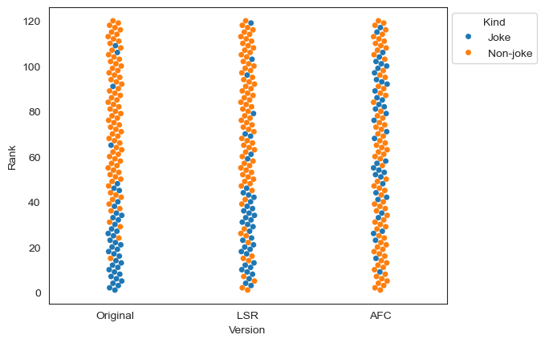

```python
# produce the plot

# stack all dataframes for comparison plot, indicating the version they contain
origs['Version'] = 'Original'
afcs['Version'] = 'AFC'
lsrs['Version'] = 'LSR'
stacked = pd.concat([origs,lsrs,afcs])

# add a column to stacked df collapsing Sense1 and 2 into Non-joke for clarity
stacked['Kind'] = stacked['Condition'].replace(['Sense1','Sense2'],'Non-joke')

# plot
ax = sns.swarmplot(data=stacked, x='Version', y='Rank', hue='Kind', hue_order=['Joke','Non-joke'])
sns.move_legend(ax, "upper left", bbox_to_anchor=(1, 1))
plt.show()
```

#### *Figure 7. Both the original task and the LSR version rank jokes as being higher in ambiguity, but the AFC version does not.*

The plot shows that for both the original and LSR versions of the task, jokes are clustered as expected towards the bottom of the rank, indicating they are high in ambiguity. However, the AFC version produced a ranking with jokes spread all across the range of ranks, indicating it did not separate them appropriately from non-jokes.

## 4. Conclusion

The LSR method of response fully replicates both effects of interest observed in the original version of the task, showing large-very large effect sizes and decisive evidence for the jokes > non-jokes ambiguity effect indicated by its Bayes factor. The AFC method, in contrast, showed an inconsistent jokes > non-jokes ammbiguity effect, present only for one of the non-joke conditions, although the correlation between the funniness and ambiguity index was present as expected in both versions. The effect sizes and Bayes Factor strength of evidence were smaller for the AFC than the LSR method, indicating that the LSR version captures the effect better. Lastly, an analysis investigating how each method ranked jokes and non-jokes in terms of their degree of ambiguity showed that both the original task and the LSR method produced rankings where the jokes were amongst the most ambiguous items, clearly separating them from the non-jokes, that were less ambiguous in turn; in contrast, the AFC method failed to produce this separation in terms of degree of ambiguity.

Based on these observations, we have chosen to include the LSR method as part of the scanning paradigm.